# Task 1

Consider a following model:

$f(x_1, x_2) = (x_1 + x_2)^2$

Assume that $x_1, x_2 \sim U[-1,1]$ and $x_1=x_2$ (full dependency)

Calculate PD profile for variable $x_1$ in this model.

Extra task if you do not fear conditional expected values: Calculate ME and ALE profiles for variable $x_1$ in this model.

$g^1_{PD}(z) = E_{x}(f(z, x)) = \int_{-1}^1 (z + x)^2 dx = (\frac{1}{3} x^3 + zx^2 + z^2x)|_{x=-1}^{1} = 2z^2 + \frac{2}{3}$

$g^1_{ME}(z) = E_{x_2|x_1=z}(f(x_1, x_2)) = E (z + z)^2 = 4z^2$

$g^1_{ALE}(z) = \int_{-1}^z \Big(E_{x_2|x_1=v}\frac{\partial f(x_1, x_2)}{\partial x_1}\Big) dv = \int_{-1}^z \big(E_{x_2|x_1=v}(2x_1 + 2 x_2)\big)dv = \int_{-1}^z (2v + 2v) dv = 2v^2|_{v=-1}^z = 2z^2 - 2$

# Task 2

## Presentation of results

I continue working with the "Alcohol Effects On Study" dataset. As the SHAP explanations showed in [one of my previous works](https://github.com/mim-uw/eXplainableMachineLearning-2023/blob/main/Homeworks/HW2/StanislawFrejlak/Homework2.ipynb), variables which have the least consistent effects on the predictions are `absences` and `Walc` (the amount of alcohol consumed on weekends). That's why I chose these variables for the Ceteris Paribus and PDP analysis.

### Ceteris Paribus Profiles

The profiles for absences prove to be quite consistent. However, it's quite difficult to interpret where the sharp changes on the lower side of the scale come from. The most plausible explanation to me is that they are simply caused by the dataset being too small (i.e. they are random). On the other hand, the profiles for the alcohol consumptions differ quite much for various pupils. It might suggest that this variable is a subject of an interaction with some other variables

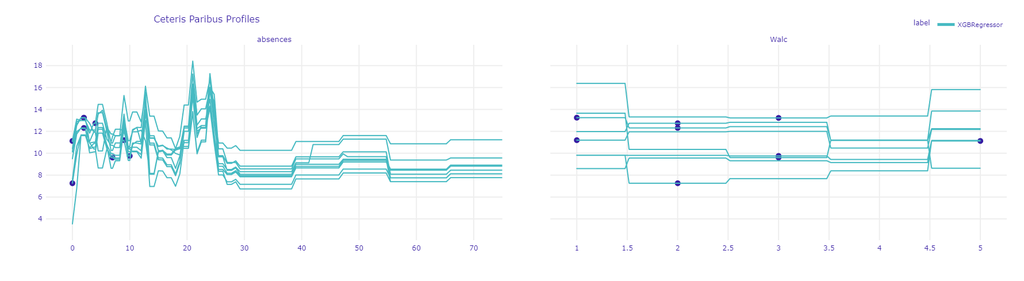

### PDP profiles

Aggregated profiles look very similar to what we've seen at the chart with Ceteris Paribus profiles. However, they don't capture the variance of the profiles connected to the alcohol consumption on weekends.

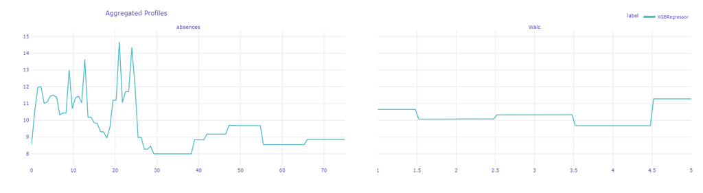

## Appendix

```python
!pip install dalex
```

```
     |████████████████████████████████| 1.0 MB 5.0 MB/s
```

```python
import dalex as dx
import xgboost

import sklearn
import pandas as pd
import numpy as np

import random
import matplotlib.pyplot as plt
```

```python
maths_dataset = pd.read_csv('Maths.csv')
```

```python
categorical_variables = ['schoolsup', 'famsup', 'paid', 'higher']
numerical_variables = ['studytime', 'failures', 'Dalc', 'Walc', 'absences']
def preprocess_dataset(df):
  new_df = df[['studytime', 'failures', 'schoolsup', 'famsup', 'paid', 'higher', 'Dalc', 'Walc', 'absences', 'G3']]\
           .sample(frac=1, random_state=0).reset_index(drop=True)
  new_df.loc[:, df.dtypes == 'object'] = new_df.select_dtypes(['object'])\
                                         .apply(lambda x: x.astype('category'))
  X, y = new_df.drop(columns='G3'), new_df.G3
  X = pd.get_dummies(X, columns=categorical_variables, drop_first=True)
  return X, y
```

```python
def boost_model_explainer(X, y):
  model = xgboost.XGBRegressor(
      n_estimators=500,
      max_depth=3,
      max_leaves=64,
      use_label_encoder=False
  )
  model.fit(X, y)
  explainer = dx.Explainer(model, X, y)
  return explainer
```

```python
def cp_explain(explainer, X, observations=(0, 1, 2, 3, 4, 314, 315, 316, 317)):
  for i in observations:
    observation = X.iloc[[i]]
    print(f"Model's prediction for Pupil %d is %.2f" % (i, explainer.predict(observation)))
  cp = explainer.predict_profile(new_observation=X.iloc[list(observations)])
  cp.plot(variables=['absences', 'Walc'])
```

```python
def pdp_explain(explainer):
  pdp = explainer.model_profile()
  pdp.plot(variables=['absences', 'Walc'])
```

```python
maths_X, maths_y = preprocess_dataset(maths_dataset)
maths_explainer = boost_model_explainer(maths_X, maths_y)
cp_explain(maths_explainer, maths_X)
pdp_explain(maths_explainer)
```

```
[23:03:38] WARNING: /workspace/src/objective/regression_obj.cu:152: reg:linear is now deprecated in favor of reg:squarederror.
Preparation of a new explainer is initiated

  -> data              : 395 rows 9 cols
  -> target variable   : Parameter 'y' was a pandas.Series. Converted to a numpy.ndarray.
  -> target variable   : 395 values
  -> model_class       : xgboost.sklearn.XGBRegressor (default)
  -> label             : Not specified, model's class short name will be used. (default)
  -> predict function  : <function yhat_default at 0x7f9a98247dd0> will be used (default)
  -> predict function  : Accepts only pandas.DataFrame, numpy.ndarray causes problems.
  -> predicted values  : min = -1.15, mean = 10.4, max = 17.6
  -> model type        : regression will be used (default)
  -> residual function : difference between y and yhat (default)
  -> residuals         : min = -11.6, mean = -8.83e-05, max = 8.32
  -> model_info        : package xgboost

A new explainer has been created!
Model's prediction for Pupil 0 is 12.74
Model's prediction for Pupil 1 is 11.12
Model's prediction for Pupil 2 is 11.19
Model's prediction for Pupil 3 is 12.31
Model's prediction for Pupil 4 is 13.25
Model's prediction for Pupil 314 is 13.23
Model's prediction for Pupil 315 is 9.75
Model's prediction for Pupil 316 is 7.26
Model's prediction for Pupil 317 is 9.60
```

[interactive chart not shown]

[interactive chart not shown]

```python
!jupyter nbconvert --to=html ./Homework4.ipynb
```